# Nota 1

### **¿Qué es EDA?**

Análisis Exploratorio de Datos, o Exploratory Data Analysis (EDA), es un proceso que consiste en explorar y comprender los datos. El EDA es fundamental en cualquier análisis de datos, ya que ayuda a comprender la calidad de los datos y a identificar áreas productivas para investigar a profundidad.

En el que:

1. Generamos preguntas sobre los datos.
2. Buscamos respuestas visualizando, transformando y modelando los datos.
3. Utilizamos lo que aprendimos para refinar las preguntas y/o generar nuevas preguntas.

#### **Acerca de las preguntas**

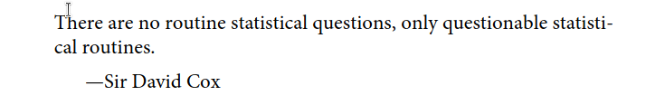

### **Tipos de Variables**

| Tipo de Variable | Descripción |
| --- | --- |
| Cualitativa Nominal | Representa categorías sin orden inherente. |
| Cualitativa Ordinal | Representa categorías con un orden específico. |
| Cuantitativa Continua | Representa valores numéricos con infinitos puntos entre ellos. |
| Cuantitativa Discreta | Representa valores numéricos con saltos finitos entre ellos. |

### **¿Cómo se presenta los datos?**

- **Variable**: Es una cantidad, cualidad o propiedad que se puede medir.
- **Valor**: Es el estado de una variable cuando se mide. El valor de una variable puede cambiar de medición a medición.
- **Observación o Caso**: Es un conjunto de mediciones realizadas bajo condiciones similares (generalmente todas las mediciones en una observación se realizan al mismo tiempo y en el mismo objeto).
- **Datos Tabulares**: Es un conjunto de valores, cada uno asociado con una variable y una observación. Los datos tabulares están ordenados si cada valor se coloca en su propia “celda”, cada variable en su propia columna y cada observación en su propia fila.

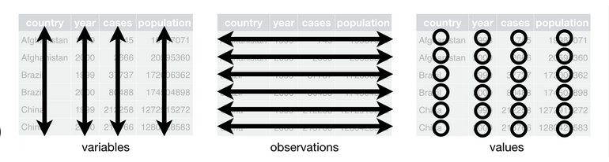

Requisitos:

```r
library(tidyverse)
```

### **Descripción tabular**

```r
head(diamonds)
```

```
## # A tibble: 6 × 10
##   carat cut       color clarity depth table price     x     y     z
##   <dbl> <ord>     <ord> <ord>   <dbl> <dbl> <int> <dbl> <dbl> <dbl>
## 1  0.23 Ideal     E     SI2      61.5    55   326  3.95  3.98  2.43
## 2  0.21 Premium   E     SI1      59.8    61   326  3.89  3.84  2.31
## 3  0.23 Good      E     VS1      56.9    65   327  4.05  4.07  2.31
## 4  0.29 Premium   I     VS2      62.4    58   334  4.2   4.23  2.63
## 5  0.31 Good      J     SI2      63.3    58   335  4.34  4.35  2.75
## 6  0.24 Very Good J     VVS2     62.8    57   336  3.94  3.96  2.48
```

```r
# Tabla de frecuencias para la variable corte

T_freq <-  diamonds %>%  # Seleccionamos la base de datos
  count(cut) %>% # Contamos obs por categoria cut
  rename(Fi = n) %>%
  mutate(Pi = round(Fi/sum(Fi), 2), Po = Pi * 100) # Agregamos las columnas

T_freq
```

```
## # A tibble: 5 × 4
##   cut          Fi    Pi    Po
##   <ord>     <int> <dbl> <dbl>
## 1 Fair       1610  0.03     3
## 2 Good       4906  0.09     9
## 3 Very Good 12082  0.22    22
## 4 Premium   13791  0.26    26
## 5 Ideal     21551  0.4     40
```

### Diagrama de barras

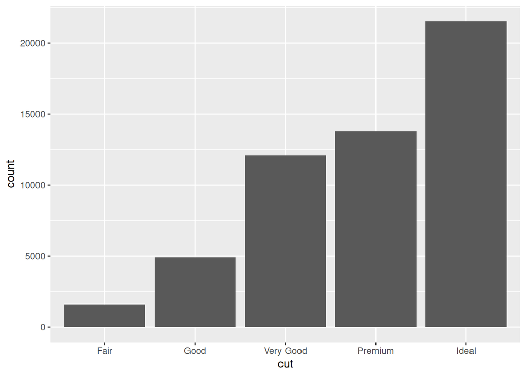

```r
ggplot(data = diamonds) +
  geom_bar(mapping = aes(x = cut))
```

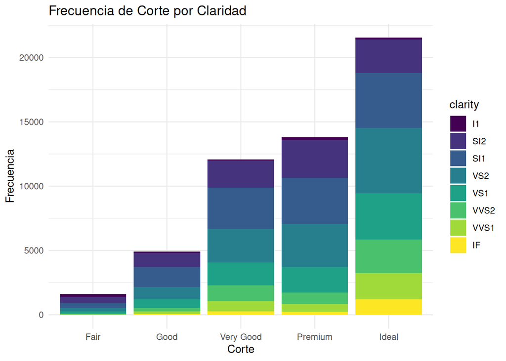

```r
ggplot(data = diamonds) +
  geom_bar(mapping = aes(x = cut, fill = clarity)) +
  labs(title = "Frecuencia de Corte por Claridad",
       x = "Corte",
       y = "Frecuencia") +
  theme_minimal()
```

```r
head(mtcars)
```

```
##                    mpg cyl disp  hp drat    wt  qsec vs am gear carb
## Mazda RX4         21.0   6  160 110 3.90 2.620 16.46  0  1    4    4
## Mazda RX4 Wag     21.0   6  160 110 3.90 2.875 17.02  0  1    4    4
## Datsun 710        22.8   4  108  93 3.85 2.320 18.61  1  1    4    1
## Hornet 4 Drive    21.4   6  258 110 3.08 3.215 19.44  1  0    3    1
## Hornet Sportabout 18.7   8  360 175 3.15 3.440 17.02  0  0    3    2
## Valiant           18.1   6  225 105 2.76 3.460 20.22  1  0    3    1
```

# Porque no utilizar una variable del dataframe diamonds

# Son muchas observaciones y todas presentan mucha variabilidad

# Rango, Varianza Medidas de dispersión

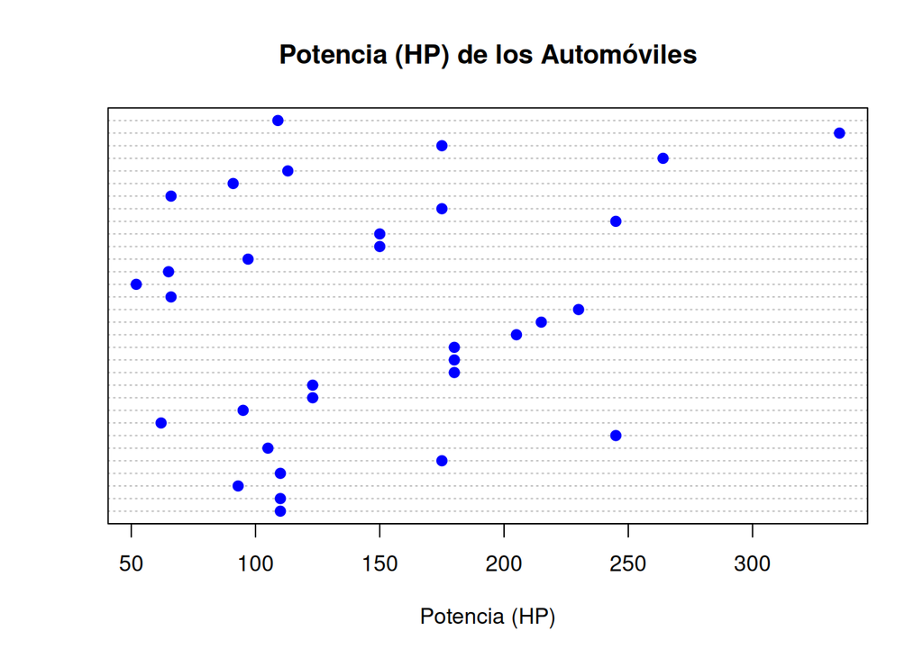

```r
dotchart((mtcars$hp),
         main = "Potencia (HP) de los Automóviles",
         xlab = "Potencia (HP)", pch = 19, col = "blue")
```

### Diagrama de tallo y hojas

```r
# Crear un diagrama de hojas de la variable 'hp' del conjunto de datos mtcars
stem(mtcars$hp, scale = 2)
```

```
##
##   The decimal point is 1 digit(s) to the right of the |
##
##    4 | 2
##    6 | 2566
##    8 | 1357
##   10 | 590003
##   12 | 33
##   14 | 00
##   16 | 555
##   18 | 000
##   20 | 55
##   22 | 0
##   24 | 55
##   26 | 4
##   28 |
##   30 |
##   32 | 5
```